# Intensity Based Genomic prediction models

This Document contains code and data needed to reproduce results from Angarita Barajas et al. Estimation of indirect social genetic effects for skin lesion count in group-housed pigs by quantifying behavioral interactions.

## 1. Load packages

Make sure to put all data in the working folder set below:

Load G matrix (VanRaden,2008), R object: G, class: matrix, Dimension 1079

Phenotypes: Lesion score log(y+1) file, finisher post-mixing, R object: lcount.data

```r
rm(list = ls())
#setwd("C:\\Users\\marti\\OneDrive\\Documents\\phenomics\\Belcy\\paper\\data")
setwd("~/Documents/Belcy_MSU_HCPP/2_Files_Matrix_Estimation_Varcomponents_Reml/Files_github_SGE/")
# 1. load library and files and matrix
library(regress)
library(gwaR)
library(Matrix)
library(MASS)
load("G_matrix.Rdata")
load("lesion_Count_Data.Rdata")
# 1.3.1. Matrix in Reciprocal fight behavior, R object:Zc.RF.Mix, class: matrix
load("Zc_Undirectional_Mix.Rdata")
# 1.3.2. Matrix in Attacks beharior, R object:Zc.ATB.Mix, class: matrix
load("Zc_Directional_Mix.Rdata")
# 1.3.3. Matrix uniform social interaction, R object:Zc.Unif.Big, class: matrix
load("Zc_Uniform_undir_Mix.Rdata")
```

## 2. Estimating (co)variance components with Direct Genetic Effect model (DGE) for one trait (anterior lesions)

This is the classical animal model implemented by our package gwaR. It includes random effects of pen, fixed effect of sex, rep (batch), pre-mix lesion count, and observers, interaction time in reciprocal fight behavior as covariate and, of course, a genetic additive effect.

```r
# 2.1. (co)variance components Anterior lesion count trait
gbfl.covRF<-gblup(rsp = "Finisher_Post_Front_ls", data = lcount.data,
                  design = c(y ~ Sex + Rep + Finisher_Pre_Front_ls + RFight.std +
                               Finisher_Pre_Obs:Finisher_Post_Obs+Finisher_Wt,
                             ~ Finisher_Pen), G=G, pos= c(T,T,T))
varcomp(gbfl.covRF)
```

```
##                Estimate   StdError  prop.var         se
## G            0.05932713 0.01776949 0.1960116 0.05566109
## Finisher_Pen 0.03303747 0.01056194 0.1091529 0.03277126
## In           0.21030695 0.01592929 0.6948355 0.07229110
```

## 3. Fitting traditional Social Genetic Effect model (TSGE) including interactio time in reciprocal fight as covariate

This are the traditional model with uniform Zc

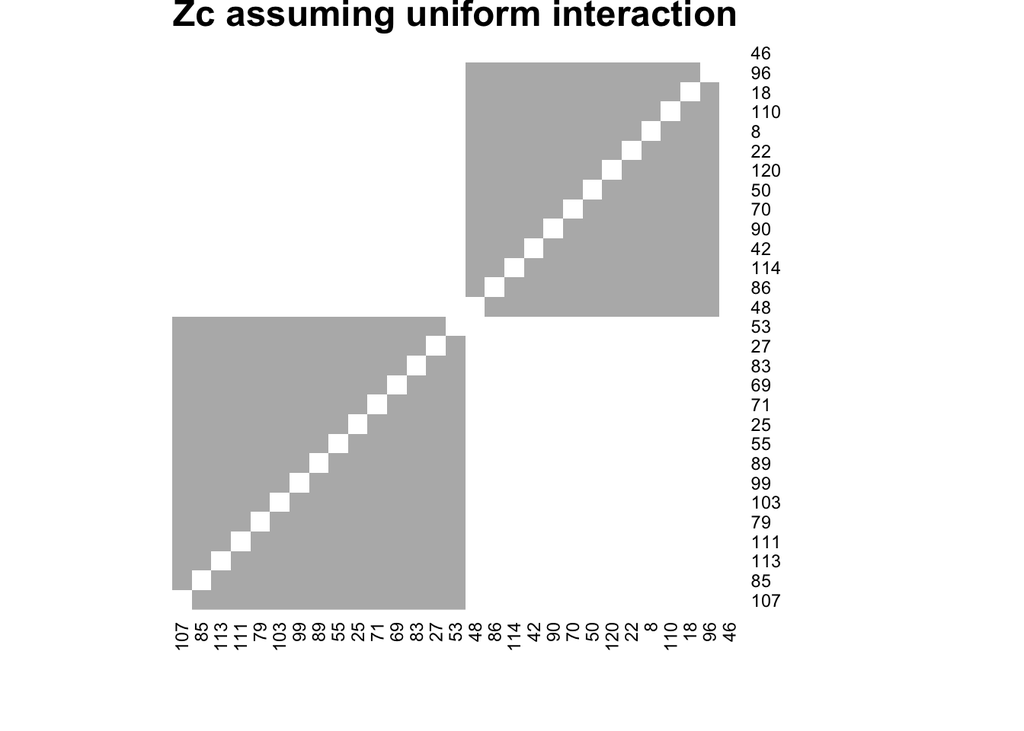

```r
#source("C:\\Users\\marti\\OneDrive\\Documents\\phenomics\\Belcy\\paper\\Functions_Reml_EM.R")
source("Functions_Reml_EM.R")
Zunif.st<-st.Zcmat(Zc.Unif.Big)

#example of incidence matrix for 2 social groups
heatmap(1/Zc.Unif.Big[1:29,1:29],symm=T,col=gray.colors(32,start=0,end=1),Rowv=NA,Colv = NA,main="Zc assuming uniform interaction")
```

```r
# fit model Anterior lesion count trait (300 iter)
flcov.tsgeRF<-igest(gbfl.covRF,Zunif.st,tol = 10^-5,k_iter = 300)
```

```
## [1] "The Tolerance criterion has been met"
```

```r
# 3.1. Variance-covariance matrix and standard error for estimates
invImat(flcov.tsgeRF)
```

```
## $Im
##             sigma u   sigma c  sigma uc   sigma p    sigma e
## sigma u  11675.8902  619.9493 -1691.929  501.5791  3214.8891
## sigma c    619.9493 8257.6718  2389.469  501.5791   508.2375
## sigma uc -1691.9288 2389.4688  6917.925 3795.2233 -1569.7666
## sigma p    501.5791  501.5791  3795.223 9905.6367   778.2341
## sigma e   3214.8891  508.2375 -1569.767  778.2341  6078.7430
##
## $VC
##                sigma u       sigma c      sigma uc       sigma p
## sigma u   1.028391e-04 -1.131513e-05  2.434467e-05 -1.036115e-05
## sigma c  -1.131513e-05  1.426495e-04 -7.050949e-05  2.248823e-05
## sigma uc  2.434467e-05 -7.050949e-05  2.430512e-04 -9.613421e-05
## sigma p  -1.036115e-05  2.248823e-05 -9.613421e-05  1.402495e-04
## sigma e  -4.582967e-05 -2.702985e-05  6.809283e-05 -3.918156e-05
##                sigma e
## sigma u  -4.582967e-05
## sigma c  -2.702985e-05
## sigma uc  6.809283e-05
## sigma p  -3.918156e-05
## sigma e   2.136062e-04
##
## $varhat
##               Estimate  Std Error
## sigma u   0.0573377410 0.01014096
## sigma c   0.0254099210 0.01194360
## sigma uc -0.0004003559 0.01559010
## sigma p   0.0099370196 0.01184270
## sigma e   0.2100684539 0.01461527
##
## attr(,"class")
## [1] "sgblup"
```

```r
# 3.2. Heritability and standard error
varcompreml(flcov.tsgeRF)
```

```
##          Estimates  Std.Error   prop.var         se
## sigma u 0.05733774 0.01014096 0.20673930 0.03660582
## sigma p 0.00993702 0.01184270 0.03582932 0.04179058
## sigma e 0.21006845 0.01461527 0.75743138 0.06042105
```

```r
# 3.3. Correlation between  direct and social genetic effect and standard error
varcovrml(flcov.tsgeRF)
```

```
## $correlation
## [1] -0.01048876
##
## $St.Error
## [1] 0.4076554
```

## 4. Fitting intensity-based Social Genetic Effect model (ISGE) for one trait

This are the models proposed in the paper. We first need to load new functions to add the social genetic effects to the base

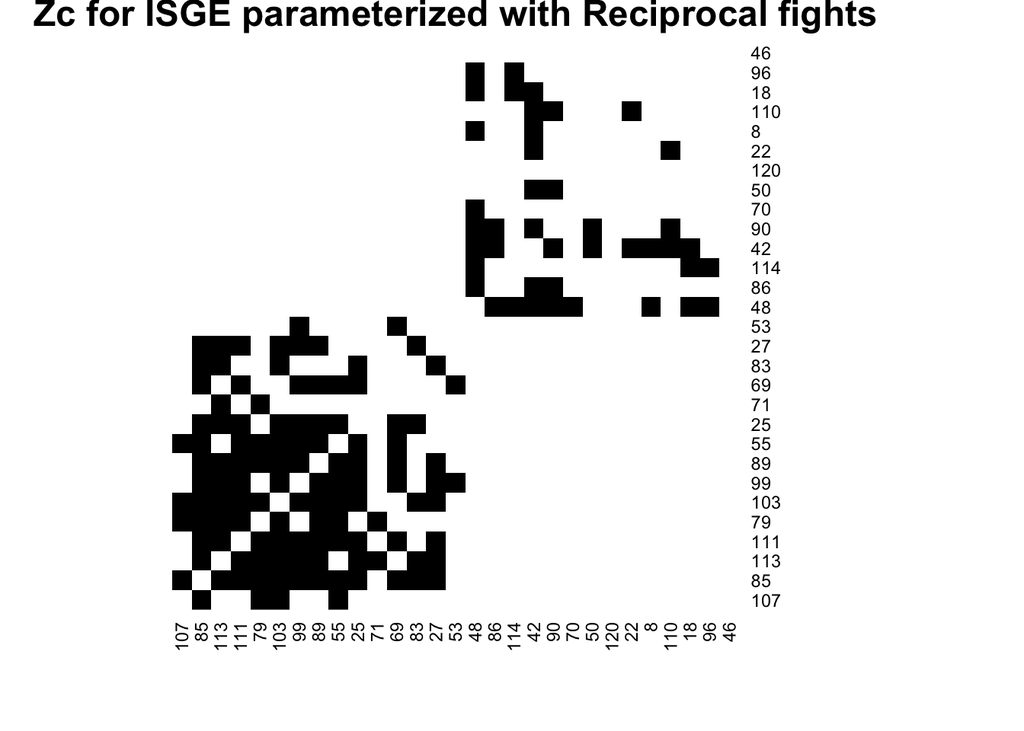

```r
# 4.1 Standardaized interaction social matrix
Zcst.RF<-st.Zcmat(Zc.RF.Mix)
#example of incidence matrix for 2 social groups, accounting for actual social interactions
heatmap(1/Zc.RF.Mix[1:29,1:29],symm=T,col=gray.colors(32,start=0,end=1),Rowv=NA,Colv = NA,main="Zc for ISGE parameterized with Reciprocal fights")
```

```r
# fit model (max: 400 iter)
flcov.isgeRF<-igest(gbfl.covRF,Zcst.RF,tol = 10^-5,k_iter = 400)
```

```
## [1] "The Tolerance criterion has been met"
```

```r
# 4.1. Variance-covariance matrix and standard error for estimates
#invImat(flcov.isgeRF)
# 4.2. Heritability and standard error
varcompreml(flcov.isgeRF)
```

```
##          Estimates   Std.Error   prop.var         se
## sigma u 0.08399551 0.008572486 0.28881504 0.03151332
## sigma p 0.02664977 0.012968820 0.09163412 0.04138893
## sigma e 0.18018274 0.013282498 0.61955084 0.04622899
```

```r
# 4.3. Correlation genetic direct and Indirect and standard error
varcovrml(flcov.isgeRF)
```

```
## $correlation
## [1] 0.8771786
##
## $St.Error
## [1] 0.1275937
```